# GeoMx Dataset and Normalization

# Summary

The purpose of this notebook is to generate the main GeoMx object containing all data collected and perform initial quality control and normalization.

# 1. Introduction

This analysis is based on the following Bioconductor vignette:

[Analyzing GeoMx-NGS RNA Expression Data with GeomxTools (bioconductor.org)](https://www.bioconductor.org/packages/release/workflows/vignettes/GeoMxWorkflows/inst/doc/GeomxTools_RNA-NGS_Analysis.html#5_Normalization)

Griswold M, Reeves J, Divakar P, Ortogero N, Yang Z, Zimmerman S, Vitancol R, David H (2023). GeoMxWorkflows: GeoMx Digital Spatial Profiler (DSP) data analysis workflows. doi:10.18129/B9.bioc.GeoMxWorkflows, R package version 1.8.0, https://bioconductor.org/packages/GeoMxWorkflows.

We analyze four different anatomical regions of the Fallopian tube, from most proximal to most distal: isthmus, ampulla, infundibulum, and fimbria.

Slides are stained for markers of Ciliated (FOXJ1) and Secretory (PAX8) cells and regions of interest are segmented based on these markers.

This script takes input files (dccs, annotations, and pkc files) and creates a GeoMx Data object. It then performs several filtering and quality control steps following the recommendations provided by Nanostring. Finally, the output is normalized to create the final dataset.

# 1.1 Required Packages

Run the following script to install packages as needed. If asked to make further installations, type y for “yes” or “a” for all updates, as needed.

```r
if (!require("BiocManager", quietly = TRUE))
    install.packages("BiocManager")
# # The following initializes most up to date version of Bioc
BiocManager::install()
a
BiocManager::install("NanoStringNCTools")
BiocManager::install("GeomxTools")
BiocManager::install("GeoMxWorkflows")
# Note:
# Need to install package lme4, numderiv
library(NanoStringNCTools)
library(GeomxTools)
library(GeoMxWorkflows)

if(packageVersion("GeomxTools") < "2.1" &
   packageVersion("GeoMxWorkflows") >= "1.0.1"){
    stop("GeomxTools and Workflow versions do not match. Please use the same version.
    This workflow is meant to be used with most current version of packages.
    If you are using an older version of Bioconductor please reinstall GeoMxWorkflows and use vignette(GeoMxWorkflows) instead")
}

if(packageVersion("GeomxTools") > "2.1" &
   packageVersion("GeoMxWorkflows") <= "1.0.1"){
    stop("GeomxTools and Workflow versions do not match.
         Please use the same version, see install instructions above.")

    # to remove current package version
        # remove.packages("GeomxTools")
        # remove.packages("GeonMxWorkflows")
    # see install instructions above
}
```

```r
# create tables
library(knitr)

# general data manipulation
library(tidyverse)


# read in files
library(writexl)
library(here)


# create graphs
library(ggforce)
library(umap)
library(Rtsne)
library(patchwork)
```

## 1.2 Loading Data

Run to create the necessary folder to place documents inside.

```r
# Create main folder ("data_input")

ifelse(!dir.exists("all_data_input"), dir.create("all_data_input"), "Folder exists already")
```

```
[1] "Folder exists already"
```

```r
# create subfolders: dccs, pks, annotation

ifelse(!dir.exists("all_data_input/dccs"), dir.create("all_data_input/dccs"), "Folder exists already")
```

```
[1] "Folder exists already"
```

```r
ifelse(!dir.exists("all_data_input/pkcs"), dir.create("all_data_input/pkcs"), "Folder exists already")
```

```
[1] "Folder exists already"
```

```r
ifelse(!dir.exists("all_data_input/annotation"), dir.create("all_data_input/annotation"), "Folder exists already")
```

```
[1] "Folder exists already"
```

We need three different types of files to create the initial dataset:

- DCCs files – these contain the expression count data and some info about sequencing data from the next gen sequencing platform used.
- PKCs – the probe assay metadata, which describes which gene targets are present in the data, find at the following link: [GeoMx DSP Configuration Files | NanoString](https://nanostring.com/products/geomx-digital-spatial-profiler/geomx-dsp-configuration-files/)

  (Do not bother to unzip, place in the appropriate file as is.)
- Annotation file - this will contain information about the tissue, segment area and nuclei count, and any other info you choose to provide.

We are just going to load all of the dcc files available along with basic annotations for all, then remove unneeded dccs later on.

Now, let’s test this to see if we can successfully create the GeoMx dataset object from these files.

```r
#
# The following function takes your directory and appends data_input

datadir <- here::here("all_data_input")

# automatically list files in each directory for use
DCCFiles <- dir(here::here(datadir, "dccs"), pattern = "*.dcc",
                full.names = TRUE, recursive = TRUE)


PKCFiles <- dir(here::here(datadir, "pkcs"), pattern = ".pkc$",
                                full.names = TRUE, recursive = TRUE)

SampleAnnotationFile <- dir(here::here(datadir, "annotation"), pattern = ".xlsx$",
      full.names = TRUE, recursive = TRUE)
```

Testing creation of `readNanoStringGeoMxSet` object. If you get errors saying files are missing or do not have any count info, check to make sure all .dcc files are in the folder (and that you have copied the correct ones).

```r
#load data


all_data <-
    readNanoStringGeoMxSet(dccFiles = DCCFiles,
                           pkcFiles = PKCFiles,
                           phenoDataFile = SampleAnnotationFile,
                           phenoDataSheet = "Sheet1", # make sure this matches doc
                           phenoDataDccColName = "Sample_ID",
                           protocolDataColNames = c("aoi", "roi"),
                           experimentDataColNames = c("panel"))
```

Note: The DCC file “DSP-1001660037560-B-A07.dcc” has no counts due to an unresolvable sequencing problem.

# 2. Study Design

Nanostring recommends checking the PKC files to ensure the expected ones have been loaded.

```r
# make sure you loaded knitr using library(knitr)

pkcs <- annotation(all_data)
modules <- gsub(".pkc", "", pkcs)
kable(data.frame(PKCs = pkcs, modules = modules))
```

| PKCs | modules |
| --- | --- |
| Hs_R_NGS_CTA_v1.0.pkc | Hs_R_NGS_CTA_v1.0 |

```r
NA
```

```r
# Rename all_data so we don't mess up the original

preQC_data <- all_data

# Access PhenoData

pheno_data <- pData(all_data)

# We should also simplify patient names

pheno_data <- pheno_data |>
  mutate(
    shortRegion = fct_recode(region, "Amp" = "Ampulla",
                              "Inf" = "Infundibulum",
                              "Fimb" = "Fimbria",
                              "Isth" = "Isthmus"
                              )
    )

# update PhenoData in GeoMx object

pData(preQC_data) <- pheno_data


#Split into all, disc, and valid



preQC_all <- preQC_data[, pData(preQC_data)$Patient != "P6"]

preQC_discovery <-  preQC_all[, pData(preQC_all)$dataset == "discovery"]

preQC_validation <- preQC_all[, pData(preQC_all)$dataset == "validation"]
```

```r
count_mat <- dplyr::count(pData(preQC_data), Patient, region, segment)

kable(count_mat)
```

| Patient | region | segment | n |
| --- | --- | --- | --- |
| P1 | Ampulla | Ciliated | 3 |
| P1 | Ampulla | Secretory | 3 |
| P1 | Fimbria | Ciliated | 3 |
| P1 | Fimbria | Secretory | 3 |
| P1 | Infundibulum | Ciliated | 3 |
| P1 | Infundibulum | Secretory | 3 |
| P1 | Isthmus | Ciliated | 6 |
| P1 | Isthmus | Secretory | 6 |
| P2 | Ampulla | Ciliated | 7 |
| P2 | Ampulla | Secretory | 4 |
| P2 | Fimbria | Ciliated | 4 |
| P2 | Fimbria | Secretory | 4 |
| P2 | Infundibulum | Ciliated | 4 |
| P2 | Infundibulum | Secretory | 4 |
| P2 | Isthmus | Ciliated | 7 |
| P2 | Isthmus | Secretory | 7 |
| P3 | Ampulla | Ciliated | 4 |
| P3 | Ampulla | Secretory | 4 |
| P3 | Fimbria | Ciliated | 6 |
| P3 | Fimbria | Secretory | 3 |
| P3 | Infundibulum | Ciliated | 3 |
| P3 | Infundibulum | Secretory | 3 |
| P3 | Isthmus | Ciliated | 8 |
| P3 | Isthmus | Secretory | 8 |
| P4 | Ampulla | Ciliated | 3 |
| P4 | Ampulla | Secretory | 3 |
| P4 | Fimbria | Ciliated | 3 |
| P4 | Fimbria | Secretory | 2 |
| P4 | Infundibulum | Ciliated | 3 |
| P4 | Infundibulum | Secretory | 3 |
| P4 | Isthmus | Ciliated | 2 |
| P4 | Isthmus | Secretory | 5 |
| P5 | Ampulla | Ciliated | 3 |
| P5 | Ampulla | Secretory | 3 |
| P5 | Fimbria | Ciliated | 3 |
| P5 | Fimbria | Secretory | 3 |
| P5 | Infundibulum | Ciliated | 3 |
| P5 | Infundibulum | Secretory | 3 |
| P5 | Isthmus | Ciliated | 3 |
| P5 | Isthmus | Secretory | 3 |
| P6 | Ampulla | Ciliated | 3 |
| P6 | Ampulla | Secretory | 3 |
| P6 | Fimbria | Ciliated | 3 |
| P6 | Fimbria | Secretory | 3 |
| P6 | Infundibulum | Ciliated | 3 |
| P6 | Infundibulum | Secretory | 3 |
| P6 | Isthmus | Ciliated | 3 |
| P6 | Isthmus | Secretory | 3 |
| P7 | Ampulla | Ciliated | 3 |
| P7 | Ampulla | Secretory | 3 |
| P7 | Fimbria | Ciliated | 3 |
| P7 | Fimbria | Secretory | 3 |
| P7 | Infundibulum | Ciliated | 3 |
| P7 | Infundibulum | Secretory | 3 |
| P7 | Isthmus | Ciliated | 2 |
| P7 | Isthmus | Secretory | 2 |

```r
NA
NA
```

Save the Completed Object;

This is the object for all Anatomical studies, before QC, probe merging, or filtering!

```r
#save(preQC_data, file = "all_preQC.Rdata")
```

## 2.1 Sample Overview

Now that we have loaded the data, we can visually summarize the experimental design for our dataset to look at the different types of samples and ROI/AOI segments that have been profiled. We present this information in a Sankey diagram.

Might try:

[Sankey Diagram for energy consumption – the R Graph Gallery (r-graph-gallery.com)](https://r-graph-gallery.com/323-sankey-diagram-with-the-networkd3-library.html)

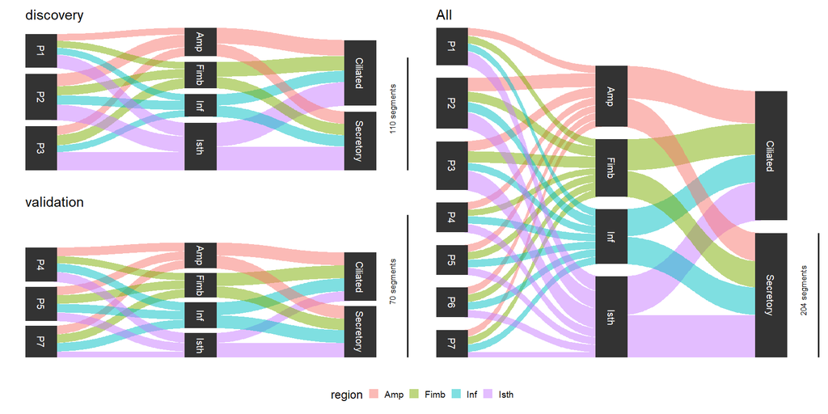

```r
# function to create Sankey ploy
create_sankey <- function(geomx_object){

  count_mat <- dplyr::count(pData(geomx_object), Patient, region = shortRegion, segment)
  input_table <- gather_set_data(count_mat, 1:3)

  ggplot(input_table, aes(x, id = id, split = y, value = n)) +
    geom_parallel_sets(aes(fill = region), alpha = 0.5, axis.width = 0.1) +
    geom_parallel_sets_axes(axis.width = 0.2) +
    geom_parallel_sets_labels(color = "white", size = 6) +
    theme_classic(base_size = 20) +
    theme(legend.position = "bottom",
          axis.ticks.y = element_blank(),
          axis.line = element_blank(),
          axis.text.y = element_blank()) +
    scale_y_continuous(expand = expansion(0)) +
    scale_x_discrete(expand = expansion(0)) +
    labs(x = "", y = "") +
    annotate(geom = "segment", x = 3.3, xend = 3.3,
             y = 0, yend = 100, lwd = 2) +
    annotate(geom = "text", x = 3.2, y = 50, angle = 90, size = 5,
             hjust = 0.4, label = paste0(sum(count_mat$n), " segments"))
}


Sankey1 <- create_sankey(preQC_data) + ggtitle("All")
Sankey2 <- create_sankey(preQC_discovery) + ggtitle("discovery")
Sankey3 <- create_sankey(preQC_validation) + ggtitle("validation")

((Sankey2 / Sankey3) | Sankey1) / guide_area()+
  plot_layout(guides = 'collect')+
  plot_layout(heights = c(12,1))
```

```r
NA
NA
NA
```

# 3. QC and Pre-Processing

There are three sets of pre-process workflow for GeoMx data. In the first part, faulty segments are removed and genes are selected based on Quality Control.

First, however, we must shift all counts of 0 to 1 (this permits downstream transformations.

```r
# shift counts to one

preQC_all <- shiftCountsOne(preQC_all, useDALogic = TRUE)


preQC_discovery <- shiftCountsOne(preQC_discovery, useDALogic = TRUE)


preQC_validation <- shiftCountsOne(preQC_validation, useDALogic = TRUE)
```

## 3.1 Segment QC

Assess sequencing quality and adequate tissue sampling for every ROI/AOI segment.

## 3.2 Select Segment QC

First, we select the QC parameter cutoffs, against which our ROI/AOI segments will be tested and flagged appropriately. We have selected the appropriate study-specific parameters for this study.

```r
# Default QC cutoffs are commented in () adjacent to the respective parameters
# study-specific values were selected after visualizing the QC results in more
# detail below

QC_params <-
    list(minSegmentReads = 1000, # Minimum number of reads (1000)
         percentTrimmed = 80,    # Minimum % of reads trimmed (80%)
         percentStitched = 80,   # Minimum % of reads stitched (80%)
         percentAligned = 75,    # Minimum % of reads aligned (80%)
         percentSaturation = 50, # Minimum sequencing saturation (50%)
         minNegativeCount = 1,   # Minimum negative control counts (10)
         maxNTCCount = 3000,     # Maximum counts observed in NTC well (1000)
         minNuclei = 20,         # Minimum # of nuclei estimated (100)
         minArea = 1000)         # Minimum segment area (5000)


#ALL Flags
preQC_all <-
    setSegmentQCFlags(preQC_all,
                      qcCutoffs = QC_params)
# Discovery Flags

preQC_discovery <-
    setSegmentQCFlags(preQC_discovery,
                      qcCutoffs = QC_params)

# Validation Flags

preQC_validation <-
    setSegmentQCFlags(preQC_validation,
                      qcCutoffs = QC_params)



# Collate QC Results
QCResults_All <- protocolData(preQC_all)[["QCFlags"]]
QCResults_Disc <- protocolData(preQC_discovery)[["QCFlags"]]
QCResults_Valid <- protocolData(preQC_validation)[["QCFlags"]]
```

```r
flag_columns <- colnames(QCResults_All)
QC_Summary_All <- data.frame(Pass = colSums(!QCResults_All[, flag_columns], na.rm = TRUE),
                         Warning = colSums(QCResults_All[, flag_columns], na.rm = TRUE))
QCResults_All$QCStatus <- apply(QCResults_All, 1L, function(x) {
    ifelse(sum(x) == 0L, "PASS", "WARNING")
})
QC_Summary_All["TOTAL FLAGS", ] <-
    c(sum(QCResults_All[, "QCStatus"] == "PASS", na.rm = TRUE),
      sum(QCResults_All[, "QCStatus"] == "WARNING", na.rm = TRUE))
```

```r
flag_columns <- colnames(QCResults_Disc)
QC_Summary_Disc <- data.frame(Pass = colSums(!QCResults_Disc[, flag_columns], na.rm = TRUE),
                         Warning = colSums(QCResults_Disc[, flag_columns], na.rm = TRUE))
QCResults_Disc$QCStatus <- apply(QCResults_Disc, 1L, function(x) {
    ifelse(sum(x) == 0L, "PASS", "WARNING")
})
QC_Summary_Disc["TOTAL FLAGS", ] <-
    c(sum(QCResults_Disc[, "QCStatus"] == "PASS", na.rm = TRUE),
      sum(QCResults_Disc[, "QCStatus"] == "WARNING", na.rm = TRUE))
```

```r
flag_columns <- colnames(QCResults_Valid)
QC_Summary_Valid <- data.frame(Pass = colSums(!QCResults_Valid[, flag_columns], na.rm = TRUE),
                         Warning = colSums(QCResults_Valid[, flag_columns], na.rm = TRUE))
QCResults_Valid$QCStatus <- apply(QCResults_Valid, 1L, function(x) {
    ifelse(sum(x) == 0L, "PASS", "WARNING")
})
QC_Summary_Valid["TOTAL FLAGS", ] <-
    c(sum(QCResults_Valid[, "QCStatus"] == "PASS", na.rm = TRUE),
      sum(QCResults_Valid[, "QCStatus"] == "WARNING", na.rm = TRUE))
```

### 3.2.1 Visualize Segment QC

Before excluding any low-performing ROI/AOI segments, we visualize the distributions of the data for the different QC parameters. Note that the “Select Segment QC” and “Visualize Segment QC” sections are performed in parallel to fully understand low-performing segments for a given study. Iteration may follow to select the study-specific QC cutoffs.

For QC visualization, we write a quick function to draw histograms of our data.

```r
col_by <- "dataset"

# Graphical summaries of QC statistics plot function
QC_histogram <- function(assay_data = NULL,
                         annotation = NULL,
                         fill_by = NULL,
                         thr = NULL,
                         scale_trans = NULL) {
    plt <- ggplot(assay_data,
                  aes_string(x = paste0("unlist(`", annotation, "`)"),
                             fill = fill_by)) +
        geom_histogram(bins = 50) +
        geom_vline(xintercept = thr, lty = "dashed", color = "black") +
        theme_bw() + guides(fill = "none") +
        facet_wrap(as.formula(paste("~", fill_by)), nrow = 4) +
        labs(x = annotation, y = "Segments, #", title = annotation)+
        scale_fill_manual(values = c("discovery" = "purple", "validation" = "darkorange"))
    if(!is.null(scale_trans)) {
        plt <- plt +
            scale_x_continuous(trans = scale_trans)
    }
    plt
}
```

Now we explore each of the QC metrics for the segments.

```r
QC_plot <- function(preQC_data){
  Trimmed <- QC_histogram(sData(preQC_data), "Trimmed (%)", col_by, 80 )
  Stiched <- QC_histogram(sData(preQC_data), "Stitched (%)", col_by, 80)
  Aligned <- QC_histogram(sData(preQC_data), "Aligned (%)", col_by, 75)
  Saturated <- QC_histogram(sData(preQC_data), "Saturated (%)", col_by, 50) +
    labs(title = "Sequencing Saturation (%)",
         x = "Sequencing Saturation (%)")
  Area <- QC_histogram(sData(preQC_data), "Area", col_by, 1000, scale_trans = "log10")
  Nuclei <- QC_histogram(sData(preQC_data), "nuclei", col_by, 20)

  Trimmed + Stiched + Aligned + Saturated + Area + Nuclei


}
```

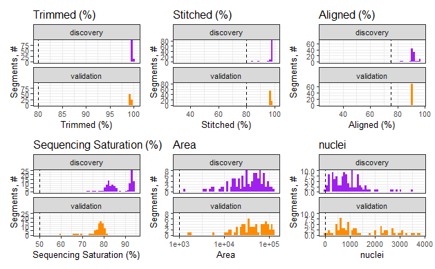

```r
QC_plot(preQC_data = preQC_all)
```

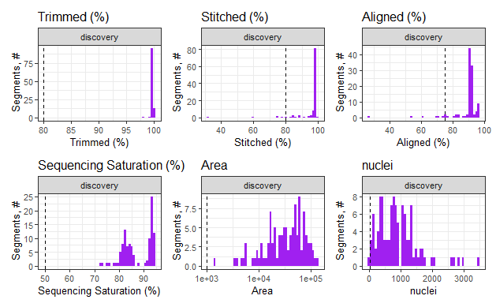

```r
QC_plot(preQC_data = preQC_discovery)
```

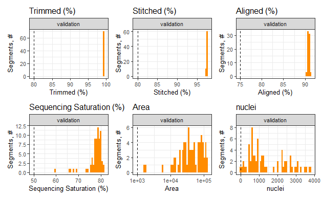

```r
QC_plot(preQC_data = preQC_validation)
```

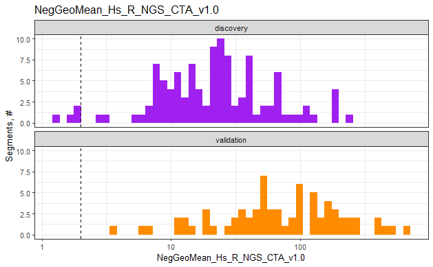

```r
# calculate the negative geometric means for each module
negativeGeoMeans_all <-
    esBy(negativeControlSubset(preQC_all),
         GROUP = "Module",
         FUN = function(x) {
             assayDataApply(x, MARGIN = 2, FUN = ngeoMean, elt = "exprs")
         })
protocolData(preQC_all)[["NegGeoMean"]] <- negativeGeoMeans_all

# explicitly copy the Negative geoMeans from sData to pData
negCols <- paste0("NegGeoMean_", modules)
pData(preQC_all)[, negCols] <- sData(preQC_all)[["NegGeoMean"]]
for(ann in negCols) {
    plt <- QC_histogram(pData(preQC_all), ann, col_by, 2, scale_trans = "log10")
    print(plt)
}
```

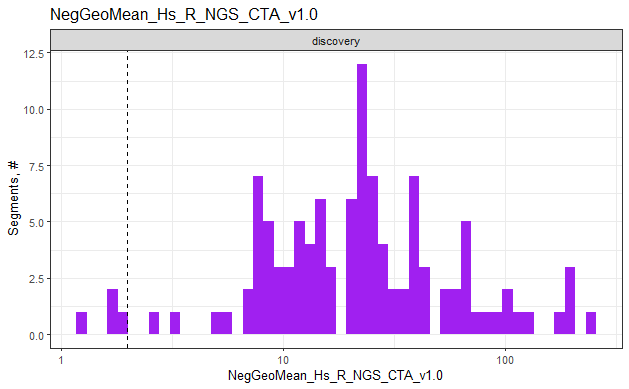

```r
# calculate the negative geometric means for each module
negativeGeoMeans_disc <-
    esBy(negativeControlSubset(preQC_discovery),
         GROUP = "Module",
         FUN = function(x) {
             assayDataApply(x, MARGIN = 2, FUN = ngeoMean, elt = "exprs")
         })
protocolData(preQC_discovery)[["NegGeoMean"]] <- negativeGeoMeans_disc

# explicitly copy the Negative geoMeans from sData to pData
negCols <- paste0("NegGeoMean_", modules)
pData(preQC_discovery)[, negCols] <- sData(preQC_discovery)[["NegGeoMean"]]
for(ann in negCols) {
    plt <- QC_histogram(pData(preQC_discovery), ann, col_by, 2, scale_trans = "log10")
    print(plt)
}
```

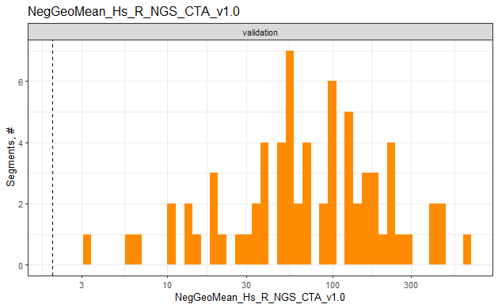

```r
# calculate the negative geometric means for each module
negativeGeoMeans_val <-
    esBy(negativeControlSubset(preQC_validation),
         GROUP = "Module",
         FUN = function(x) {
             assayDataApply(x, MARGIN = 2, FUN = ngeoMean, elt = "exprs")
         })
protocolData(preQC_validation)[["NegGeoMean"]] <- negativeGeoMeans_val

# explicitly copy the Negative geoMeans from sData to pData
negCols <- paste0("NegGeoMean_", modules)
pData(preQC_validation)[, negCols] <- sData(preQC_validation)[["NegGeoMean"]]
for(ann in negCols) {
    plt <- QC_histogram(pData(preQC_validation), ann, col_by, 2, scale_trans = "log10")
    print(plt)
}
```

```r
# detach neg_geomean columns ahead of aggregateCounts call
pData(preQC_all) <- pData(preQC_all)[, !colnames(pData(preQC_all)) %in% negCols]

# detach neg_geomean columns ahead of aggregateCounts call
pData(preQC_discovery) <- pData(preQC_discovery)[, !colnames(pData(preQC_discovery)) %in% negCols]

# detach neg_geomean columns ahead of aggregateCounts call
pData(preQC_validation) <- pData(preQC_validation)[, !colnames(pData(preQC_validation)) %in% negCols]

# show all NTC values, Freq = # of Segments with a given NTC count:
kable(table(NTC_Count = sData(preQC_all)$NTC),
      col.names = c("NTC Count ALL", "# of Segments"))
```

| NTC Count ALL | # of Segments |
| --- | --- |
| 7 | 18 |
| 16 | 32 |
| 129 | 28 |
| 254 | 70 |
| 2218 | 32 |

```r
kable(table(NTC_Count = sData(preQC_discovery)$NTC),
      col.names = c("NTC Count DISC", "# of Segments"))
```

| NTC Count DISC | # of Segments |
| --- | --- |
| 7 | 18 |
| 16 | 32 |
| 129 | 28 |
| 2218 | 32 |

```r
kable(table(NTC_Count = sData(preQC_validation)$NTC),
      col.names = c("NTC Count VALID", "# of Segments"))
```

| NTC Count VALID | # of Segments |
| --- | --- |
| 254 | 70 |

```r
NA
NA
NA
NA
```

### 3.2.2 Remove Flagged Segments

As the final step in the QC, we remove all flagged segments that do not meet the QC cutoff.

```r
all_afterQC <- preQC_all[, QCResults_All$QCStatus == "PASS"]

discovery_afterQC <- preQC_discovery[, QCResults_Disc$QCStatus == "PASS"]
validation_afterQC <- preQC_validation[, QCResults_Valid$QCStatus == "PASS"]

# Subsetting our dataset has removed samples which did not pass QC
print("all")
```

```
[1] "all"
```

```r
dim(preQC_data)
```

```
Features  Samples
    8659      204
```

```r
dim(all_afterQC)
```

```
Features  Samples
    8659      174
```

```r
print("discovery")
```

```
[1] "discovery"
```

```r
dim(preQC_discovery)
```

```
Features  Samples
    8659      110
```

```r
dim(discovery_afterQC)
```

```
Features  Samples
    8659      104
```

```r
print("validation")
```

```
[1] "validation"
```

```r
dim(preQC_validation)
```

```
Features  Samples
    8659       70
```

```r
dim(validation_afterQC)
```

```
Features  Samples
    8659       70
```

Save the object after QC

```r
save(all_afterQC, file = "all_data_afterQC.Rdata")
```

```r
count_mat_QC1 <- dplyr::count(pData(all_afterQC), Patient, region, segment)

kable(count_mat_QC1)
```

| Patient | region | segment | n |
| --- | --- | --- | --- |
| P1 | Ampulla | Ciliated | 3 |
| P1 | Ampulla | Secretory | 3 |
| P1 | Fimbria | Ciliated | 3 |
| P1 | Fimbria | Secretory | 3 |
| P1 | Infundibulum | Ciliated | 3 |
| P1 | Infundibulum | Secretory | 3 |
| P1 | Isthmus | Ciliated | 6 |
| P1 | Isthmus | Secretory | 6 |
| P2 | Ampulla | Ciliated | 5 |
| P2 | Ampulla | Secretory | 3 |
| P2 | Fimbria | Ciliated | 4 |
| P2 | Fimbria | Secretory | 4 |
| P2 | Infundibulum | Ciliated | 4 |
| P2 | Infundibulum | Secretory | 4 |
| P2 | Isthmus | Ciliated | 5 |
| P2 | Isthmus | Secretory | 6 |
| P3 | Ampulla | Ciliated | 4 |
| P3 | Ampulla | Secretory | 4 |
| P3 | Fimbria | Ciliated | 6 |
| P3 | Fimbria | Secretory | 3 |
| P3 | Infundibulum | Ciliated | 3 |
| P3 | Infundibulum | Secretory | 3 |
| P3 | Isthmus | Ciliated | 8 |
| P3 | Isthmus | Secretory | 8 |
| P4 | Ampulla | Ciliated | 3 |
| P4 | Ampulla | Secretory | 3 |
| P4 | Fimbria | Ciliated | 3 |
| P4 | Fimbria | Secretory | 2 |
| P4 | Infundibulum | Ciliated | 3 |
| P4 | Infundibulum | Secretory | 3 |
| P4 | Isthmus | Ciliated | 2 |
| P4 | Isthmus | Secretory | 5 |
| P5 | Ampulla | Ciliated | 3 |
| P5 | Ampulla | Secretory | 3 |
| P5 | Fimbria | Ciliated | 3 |
| P5 | Fimbria | Secretory | 3 |
| P5 | Infundibulum | Ciliated | 3 |
| P5 | Infundibulum | Secretory | 3 |
| P5 | Isthmus | Ciliated | 3 |
| P5 | Isthmus | Secretory | 3 |
| P7 | Ampulla | Ciliated | 3 |
| P7 | Ampulla | Secretory | 3 |
| P7 | Fimbria | Ciliated | 3 |
| P7 | Fimbria | Secretory | 3 |
| P7 | Infundibulum | Ciliated | 3 |
| P7 | Infundibulum | Secretory | 3 |
| P7 | Isthmus | Ciliated | 2 |
| P7 | Isthmus | Secretory | 2 |

```r
NA
NA
```

# 4. Probe QC

Before we summarize our data into gene-level count data, we will remove low-performing probes. In short, this QC is an outlier removal process, whereby probes are either removed entirely from the study (global) or from specific segments (local). The QC applies to gene targets for which there are multiple distinct probes representing the count for a gene per segment. In WTA data, one specific probe exists per target gene; thus, Probe QC does not apply to the endogenous genes in the panel. Rather, it is performed on the negative control probes; there are multiple probes representing our negative controls, which do not target any sequence in the genome. These probes enable calculation of the background per segment and will be important for determining gene detection downstream.

After Probe QC, there will always remain at least one probe representing every gene target. In other words, Probe QC never removes genes from your data.

### 4.1 Set Probe QC Flags

A probe is removed globally from the dataset if either of the following is true:

- the geometric mean of that probe’s counts from all segments divided by the geometric mean of all probe counts representing the target from all segments is less than 0.1
- the probe is an outlier according to the Grubb’s test in at least 20% of the segments A probe is removed locally (from a given segment) if the probe is an outlier according to the Grubb’s test in that segment.

We do not typically adjust these QC parameters.

```r
####DATASET == ALL#####

# Generally keep the qcCutoffs parameters unchanged. Set removeLocalOutliers to
# FALSE if you do not want to remove local outliers
all_afterQC <- setBioProbeQCFlags(all_afterQC,
                               qcCutoffs = list(minProbeRatio = 0.1,
                                                percentFailGrubbs = 20),
                               removeLocalOutliers = TRUE)
```

```
Processed 1278 groups out of 1762. 73% done. Time elapsed: 3s. ETA: 1s.
Processed 1726 groups out of 1762. 98% done. Time elapsed: 4s. ETA: 0s.
Processed 1762 groups out of 1762. 100% done. Time elapsed: 4s. ETA: 0s.
```

```r
ProbeQCResults <- fData(all_afterQC)[["QCFlags"]]

# Define QC table for Probe QC
qc_df <- data.frame(Passed = sum(rowSums(ProbeQCResults[, -1]) == 0),
                    Global = sum(ProbeQCResults$GlobalGrubbsOutlier),
                    Local = sum(rowSums(ProbeQCResults[, -2:-1]) > 0
                                & !ProbeQCResults$GlobalGrubbsOutlier))


####DATASET == discovery #####

discovery_afterQC <- setBioProbeQCFlags(discovery_afterQC,
                               qcCutoffs = list(minProbeRatio = 0.1,
                                                percentFailGrubbs = 20),
                               removeLocalOutliers = TRUE)

ProbeQCResults_d <- fData(discovery_afterQC)[["QCFlags"]]

# Define QC table for Probe QC
qc_df_d <- data.frame(Passed = sum(rowSums(ProbeQCResults_d[, -1]) == 0),
                    Global = sum(ProbeQCResults_d$GlobalGrubbsOutlier),
                    Local = sum(rowSums(ProbeQCResults_d[, -2:-1]) > 0
                                & !ProbeQCResults_d$GlobalGrubbsOutlier))



####DATASET == validation#####


validation_afterQC <- setBioProbeQCFlags(validation_afterQC,
                               qcCutoffs = list(minProbeRatio = 0.1,
                                                percentFailGrubbs = 20),
                               removeLocalOutliers = TRUE)

ProbeQCResults_v <- fData(validation_afterQC)[["QCFlags"]]

# Define QC table for Probe QC
qc_df_v <- data.frame(Passed = sum(rowSums(ProbeQCResults_v[, -1]) == 0),
                    Global = sum(ProbeQCResults_v$GlobalGrubbsOutlier),
                    Local = sum(rowSums(ProbeQCResults_v[, -2:-1]) > 0
                                & !ProbeQCResults_v$GlobalGrubbsOutlier))
```

We report the number of global and local outlier probes.

```r
qc_df
```

| Passed | Global | Local |
| --- | --- | --- |
| 6532 | 46 | 2081 |

```r
qc_df_d
```

| Passed | Global | Local |
| --- | --- | --- |
| 7034 | 49 | 1576 |

```r
qc_df_v
```

| Passed | Global | Local |
| --- | --- | --- |
| 7706 | 33 | 920 |

```r
NA
NA
NA
NA
```

### 4.2 Exclude Outlier Probes

```r
####DATASET == ALL####

#Subset object to exclude all that did not pass Ratio & Global testing
ProbeQCPassed <-
    subset(all_afterQC,
           fData(all_afterQC)[["QCFlags"]][,c("LowProbeRatio")] == FALSE &
               fData(all_afterQC)[["QCFlags"]][,c("GlobalGrubbsOutlier")] == FALSE)

####DATASET == ALL####

dim(all_afterQC)
```

```
Features  Samples
    8659      174
```

```r
dim(ProbeQCPassed)
```

```
Features  Samples
    8597      174
```

[output not shown]

```r
all_AfterProbeQC <- ProbeQCPassed


####DATASET == Discovery####

#Subset object to exclude all that did not pass Ratio & Global testing
ProbeQCPassed <-
    subset(discovery_afterQC,
           fData(discovery_afterQC)[["QCFlags"]][,c("LowProbeRatio")] == FALSE &
               fData(discovery_afterQC)[["QCFlags"]][,c("GlobalGrubbsOutlier")] == FALSE)


dim(discovery_afterQC)
```

```
Features  Samples
    8659      104
```

```r
dim(ProbeQCPassed)
```

```
Features  Samples
    8607      104
```

[output not shown]

```r
discovery_AfterProbeQC <- ProbeQCPassed


####DATASET == Validation####

#Subset object to exclude all that did not pass Ratio & Global testing
ProbeQCPassed <-
    subset(validation_afterQC,
           fData(validation_afterQC)[["QCFlags"]][,c("LowProbeRatio")] == FALSE &
               fData(validation_afterQC)[["QCFlags"]][,c("GlobalGrubbsOutlier")] == FALSE)


dim(validation_afterQC)
```

```
Features  Samples
    8659       70
```

```r
dim(ProbeQCPassed)
```

```
Features  Samples
    8586       70
```

[output not shown]

```r
validation_AfterProbeQC <- ProbeQCPassed
```

```r
save(all_AfterProbeQC, file = "all_AfterProbeQC.Rdata")

save(discovery_AfterProbeQC, file = "discovery_AfterProbeQC.Rdata")

save(validation_AfterProbeQC, file = "validation_AfterProbeQC.Rdata")
```

## 4.3 Create Gene Level Count Data

With our Probe QC steps complete, we will generate a gene-level count matrix. The count for any gene with multiple probes per segment is calculated as the geometric mean of those probes.

```r
target_anat_all <- aggregateCounts(all_AfterProbeQC)
target_anat_disc<- aggregateCounts(discovery_AfterProbeQC)
target_anat_valid<- aggregateCounts(validation_AfterProbeQC)



# # Check how many unique targets the object has
# length(unique(featureData(all_AfterProbeQC)[["TargetName"]]))
# #> [1] 18504
#
# # collapse to targets
# target_AnatCompData_all <- aggregateCounts(all_AfterProbeQC)
# dim(all_AfterProbeQC)
# dim(target_AnatCompData)
# #> Features  Samples
# #>    18504      229
# exprs(target_AnatCompData)[1:5, 1:2]
# #>       DSP-1001250007851-H-A02.dcc DSP-1001250007851-H-A03.dcc
# #> A2M                           485                         262
# #> NAT2                           15                          18
# #> ACADM                          31                          15
# #> ACADS                          27                          17
# #> ACAT1                          29                          24
#
```

## 4.4 Limit of Quantitation

In addition to Segment and Probe QC, we also determine the limit of quantification (LOQ) per segment. The LOQ is calculated based on the distribution of negative control probes and is intended to approximate the quantifiable limit of gene expression per segment. Please note that this process is more stable in larger segments. Likewise, the LOQ may not be as accurately reflective of true signal detection rates in segments with low negative probe counts (ex: <2). The formula for calculating the LOQ in the ith segment is:

$$LOQ_i=geomean(NegProbe_i)∗geoSD(NegProbe_i)^n$$

We typically use 2 geometric standard deviations (n=2) above the geometric mean as the LOQ, which is reasonable for most studies. We also recommend that a minimum LOQ of 2 be used if the LOQ calculated in a segment is below this threshold.

## LOQ_calc function

```r
## Create a function to calculate LOQ per module tested, then add it to the GeoMx Dataset

LOQ_calc <- function(GeoMxObj = target_anat_all, cutoff = 2, minLOQ = 2){
  # Calculate LOQ per module tested
  LOQ <- data.frame(row.names = colnames(GeoMxObj))
  for(module in modules) {
    vars <- paste0(c("NegGeoMean_", "NegGeoSD_"),
                   module)
    if(all(vars[1:2] %in% colnames(pData(GeoMxObj)))) {
        LOQ[, module] <-
            pmax(minLOQ,
                 pData(GeoMxObj)[, vars[1]] *
                     pData(GeoMxObj)[, vars[2]] ^ cutoff)
    }
    }
  pData(GeoMxObj)$LOQ <- LOQ

  return(GeoMxObj)

}

## usage example:

#target_anat_all <- LOQ_calc(GeoMxObj = target_anat_all)

# Check

#target_anat_all$LOQ
```

Now apply the function to all of the target datasets

```r
target_anat_all <- LOQ_calc(GeoMxObj = target_anat_all)
target_anat_disc <- LOQ_calc(GeoMxObj = target_anat_disc)
target_anat_valid <- LOQ_calc(GeoMxObj = target_anat_valid)
```

## 4.5 Filtering

After determining the limit of quantification (LOQ) per segment, we recommend filtering out either segments and/or genes with abnormally low signal. Filtering is an important step to focus on the true biological data of interest.

We determine the number of genes detected in each segment across the dataset.

## FUNCT: create_LOQ_matrix

```r
# this function takes a GeoMx Data object and producesa matrix with number of genes detected in each

create_LOQ_matrix <- function(GeoMxObj = target_anat_all){
  LOQ_Mat <- c()
  for(module in modules) {
    ind <- fData(GeoMxObj)$Module == module
    Mat_i <- t(esApply(GeoMxObj[ind, ], MARGIN = 1,
                       FUN = function(x) {
                           x > LOQ[, module]
                       }))
    LOQ_Mat <- rbind(LOQ_Mat, Mat_i)
  }


  LOQ_Mat <- LOQ_Mat[fData(GeoMxObj)$TargetName, ]

  return(LOQ_Mat)

}


### USAGE:
##  LOQ_Mat_all <- create_LOQ_matrix(GeoMxObj = target_anat_all)
```

```r
LOQ_Mat_all <- create_LOQ_matrix(GeoMxObj = target_anat_all)

LOQ_Mat_disc <- create_LOQ_matrix(GeoMxObj = target_anat_disc)

LOQ_Mat_valid <- create_LOQ_matrix(GeoMxObj = target_anat_valid)
```

### 4.5.2 Segment Gene Detection

We first filter out segments with exceptionally low signal. These segments will have a small fraction of panel genes detected above the LOQ relative to the other segments in the study. Let’s visualize the distribution of segments with respect to their % genes detected:

## FUNCT: gene_detection_rate()

```r
gene_detection_rate <- function(GeoMxObj = target_anat_all, LOQ_Mat = LOQ_Mat_all){
  # Save detection rate information to pheno data
  pData(GeoMxObj)$GenesDetected <-
    colSums(LOQ_Mat, na.rm = TRUE)
  pData(GeoMxObj)$GeneDetectionRate <-
    pData(GeoMxObj)$GenesDetected / nrow(GeoMxObj)

  # Determine detection thresholds: 1%, 5%, 10%, 15%, >15%
  pData(GeoMxObj)$DetectionThreshold <-
    cut(pData(GeoMxObj)$GeneDetectionRate,
        breaks = c(0, 0.01, 0.05, 0.1, 0.15, 0.20, 0.25, 1),
        labels = c("<1%", "1-5%", "5-10%", "10-15%", "16%-20%", "21%-25%", ">25%"))

  return(GeoMxObj)
}
```

```r
target_anat_all <- gene_detection_rate(GeoMxObj = target_anat_all, LOQ_Mat = LOQ_Mat_all)

target_anat_disc <- gene_detection_rate(GeoMxObj = target_anat_disc, LOQ_Mat = LOQ_Mat_disc)

target_anat_valid <- gene_detection_rate(GeoMxObj = target_anat_valid, LOQ_Mat = LOQ_Mat_valid)
```

## FUNCT: gene_detection_plot()

```r
gene_detection_plot <- function(GeoMxObj = target_anat_all){
  # stacked bar plot of different cut points (1%, 5%, 10%, 15%)
  plot <- ggplot(pData(GeoMxObj),
       aes(x = DetectionThreshold)) +
    geom_bar(aes(fill = Patient)) +
    geom_text(stat = "count", aes(label = after_stat(count)), vjust = -0.5) +
    theme_bw() +
    scale_y_continuous(expand = expansion(mult = c(0, 0.1))) +
    labs(x = "Gene Detection Rate",
         y = "Segments, #",
         fill = "Segment Type")

  return(plot)

}
```

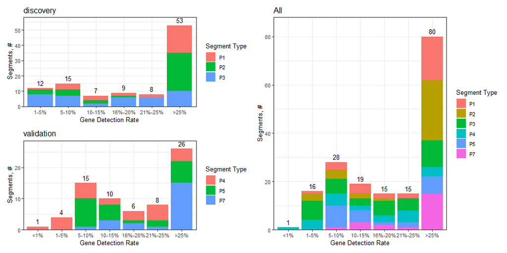

```r
d_all <- gene_detection_plot(GeoMxObj = target_anat_all) + ggtitle("All")

d_disc <- gene_detection_plot(GeoMxObj = target_anat_disc) + ggtitle("discovery")

d_valid <- gene_detection_plot(GeoMxObj = target_anat_valid) + ggtitle("validation")


((d_disc / d_valid) | d_all)
```

```r
NA
NA
NA
```

We can also create a table to review whether ciliated or secretory is most impacted.

```r
# cut percent genes detected from above
# kable(table(pData(target_AnatCompData)$DetectionThreshold,
#             pData(target_AnatCompData)$segment))
#
#
# kable(table(pData(target_AnatCompData)$DetectionThreshold,
#             pData(target_AnatCompData)$region))
```

In this example, we choose to remove segments with less than **10%** of the genes detected. Generally, 5-10% detection is a reasonable segment filtering threshold. However, based on the experimental design (e.g. segment types, size, nuclei) and tissue characteristics (e.g. type, age), these guidelines may require adjustment.

```r
## ALL

target_anat_all_0.1 <- target_anat_all[, pData(target_anat_all)$GeneDetectionRate >= .1]
print("All")
```

```
[1] "All"
```

```r
dim(target_anat_all_0.1) - dim(target_anat_all)
```

```
Features  Samples
       0      -45
```

```r
## Disc

target_anat_disc_0.1 <- target_anat_disc[, pData(target_anat_disc)$GeneDetectionRate >= .1]

print("Discovery")
```

```
[1] "Discovery"
```

```r
dim(target_anat_disc_0.1) - dim(target_anat_disc)
```

```
Features  Samples
       0      -27
```

```r
## Disc

target_anat_valid_0.1 <- target_anat_valid[, pData(target_anat_valid)$GeneDetectionRate >= .1]

print("Validation")
```

```
[1] "Validation"
```

```r
dim(target_anat_valid_0.1) - dim(target_anat_valid)
```

```
Features  Samples
       0      -20
```

Overall, the whole dataset results in two fewer samples being removed compared to discovery and validation seprately.

```r
# ALL

count_mat_filter_all <- dplyr::count(pData(target_anat_all_0.1), Patient, region = shortRegion, segment)
# gather the data and plot in order: class, slide name, region, segment
test_gr_all <- gather_set_data(count_mat_filter_all, 1:3)

# Discovery

count_mat_filter_disc <- dplyr::count(pData(target_anat_disc_0.1), Patient, region = shortRegion, segment)
test_gr_disc <- gather_set_data(count_mat_filter_disc, 1:3)

# Validation

count_mat_filter_valid <- dplyr::count(pData(target_anat_valid_0.1), Patient, region = shortRegion, segment)
test_gr_valid <- gather_set_data(count_mat_filter_valid, 1:3)
```

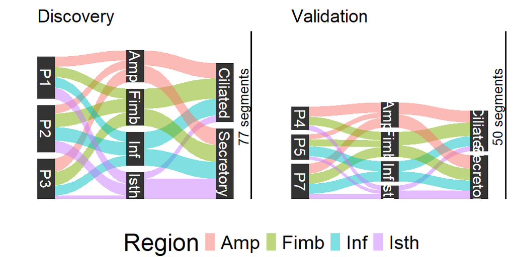

```r
sankey_diagram <- function(test_gr = test_gr_all, count_mat = count_mat_filter_all){
  plot <- ggplot(test_gr, aes(x, id = id, split = y, value = n)) +
    geom_parallel_sets(aes(fill = region), alpha = 0.5, axis.width = 0.1) +
    geom_parallel_sets_axes(axis.width = 0.2) +
    geom_parallel_sets_labels(color = "white", size = 9) +
    theme_classic(base_size = 19) +
    theme(legend.position = "bottom",
          axis.ticks.y = element_blank(),
          axis.line = element_blank(),
          axis.text.y = element_blank()) +
    scale_y_continuous(expand = expansion(0)) +
    scale_x_discrete(expand = expansion(0)) +
    labs(title = "Segment Distribution After QC", x = "", y = "", fill = "Region") +
    annotate(geom = "segment", x = 3.3, xend = 3.3,
             y = 0, yend = 100, lwd = 2) +
    annotate(geom = "text", x = 3.2, y = 55, angle = 90, size = 8,
             hjust = 0.5, label = paste0(sum(count_mat$n), " segments"))

  return(plot)
}


text_size = 40
All_Sankey <- sankey_diagram(test_gr = test_gr_all, count_mat = count_mat_filter_all) + ggtitle("All") +  theme(text=element_text(size=text_size)) + theme(plot.title = element_text(size=30))

Disc_Sankey <- sankey_diagram(test_gr = test_gr_disc, count_mat = count_mat_filter_disc) + ggtitle("Discovery") +theme(text=element_text(size=text_size))  + theme(plot.title = element_text(size=30))



Valid_Sankey <- sankey_diagram(test_gr = test_gr_valid, count_mat = count_mat_filter_valid) + ggtitle("Validation") + theme(text=element_text(size=text_size))  + theme(plot.title = element_text(size=30))



(Disc_Sankey | Valid_Sankey) /guide_area() + plot_layout(heights = c(10, 1), guides = 'collect')
```

```r
NA
NA
NA
```